# Tailor marketing strategies for upselling and cross-selling

Author: Lai Yeung

Date: January 2023

```python
%%time
from tqdm import tqdm
import pandas as pd
import numpy as np
from sklearn.preprocessing import StandardScaler
from sklearn.cluster import MiniBatchKMeans
from sklearn.metrics import silhouette_score
import matplotlib.pyplot as plt
import datashader as ds
import datashader.transfer_functions as tf
import colorcet as cc  # For color maps

# Simulate more realistic data
np.random.seed(42)
n_customers = 100000

# Use a more memory-efficient approach to generate data
data = pd.DataFrame({
    'Customer_ID': range(1, n_customers + 1),
    'Total_Spend': np.random.exponential(500, n_customers),
    'Num_Orders': np.random.poisson(5, n_customers),
    'Avg_Order_Value': np.random.normal(100, 30, n_customers),
    'Days_Since_Last_Purchase': np.random.exponential(30, n_customers),
    'Num_Product_Categories': np.random.poisson(3, n_customers),
    'Customer_Lifetime_Days': np.random.uniform(1, 1000, n_customers),
    'Website_Visits': np.random.poisson(20, n_customers),
    'Email_Open_Rate': np.random.beta(2, 5, n_customers),
    'Click_Through_Rate': np.random.beta(1, 10, n_customers),
    'Cart_Abandonment_Rate': np.random.beta(2, 3, n_customers),
    'Avg_Time_Between_Purchases': np.random.exponential(15, n_customers),
    'Highest_Single_Purchase': np.random.exponential(200, n_customers),
    'Returns_Rate': np.random.beta(1, 20, n_customers),
    'Loyalty_Program_Status': np.random.binomial(1, 0.3, n_customers)
})

data['Total_Spend'] = np.minimum(data['Total_Spend'], data['Total_Spend'])
data['Num_Orders'] = np.minimum(data['Num_Orders'], data['Num_Orders'])
data['Days_Since_Last_Purchase'] = np.minimum(data['Days_Since_Last_Purchase'], data['Days_Since_Last_Purchase'])
data['Num_Product_Categories'] = data['Num_Product_Categories'].replace(0, 1)

# Ensure logical consistency
data['Avg_Order_Value'] = data['Total_Spend'] / data['Num_Orders']
data['Highest_Single_Purchase'] = np.maximum(data['Highest_Single_Purchase'], data['Avg_Order_Value'])
data['Days_Since_Last_Purchase'] = np.minimum(data['Days_Since_Last_Purchase'], data['Customer_Lifetime_Days'])

# Handle outliers (capping at 99th percentile)
for column in data.columns:
    if data[column].dtype in ['float64', 'int64']:
        data[column] = np.minimum(data[column], data[column].quantile(0.99))

# Scale features
scaler = StandardScaler()
features = data.columns.drop(['Customer_ID', 'Loyalty_Program_Status'])
data_scaled = pd.DataFrame(scaler.fit_transform(data[features]), columns=features)
data_scaled['Loyalty_Program_Status'] = data['Loyalty_Program_Status']
```

```
Wall time: 8.38 s
```

[output not shown]

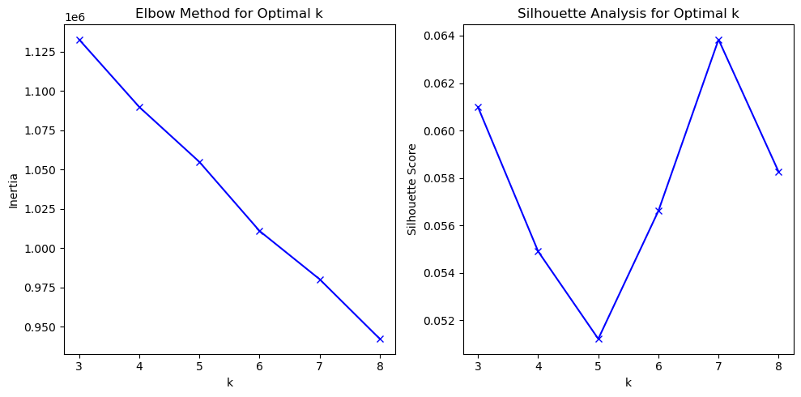

```
Wall time: 11min 54s
```

|  | Total_Spend | Num_Orders | Avg_Order_Value | Days_Since_Last_Purchase | Num_Product_Categories | Customer_Lifetime_Days | Website_Visits | Email_Open_Rate | Click_Through_Rate | Cart_Abandonment_Rate | Avg_Time_Between_Purchases | Highest_Single_Purchase | Returns_Rate | Loyalty_Program_Status |
| --- | --- | --- | --- | --- | --- | --- | --- | --- | --- | --- | --- | --- | --- | --- |
| 0 | 397.026136 | 5.042455 | 90.171936 | 25.719186 | 3.158098 | 534.002474 | 19.305761 | 0.280657 | 0.250085 | 0.416382 | 14.447765 | 228.934684 | 0.052827 | 0.295451 |
| 1 | 351.582217 | 4.965690 | 80.336136 | 21.953982 | 3.649532 | 651.558902 | 23.788704 | 0.312657 | 0.061562 | 0.354502 | 16.339328 | 215.100034 | 0.086404 | 0.300833 |
| 2 | 385.908237 | 4.528094 | 96.547590 | 72.071345 | 3.086550 | 576.480122 | 19.728246 | 0.246527 | 0.069054 | 0.489519 | 13.267807 | 232.156584 | 0.040615 | 0.295516 |
| 3 | 553.248922 | 4.580577 | 130.263289 | 19.675131 | 2.908766 | 239.369513 | 22.067673 | 0.259303 | 0.082678 | 0.385634 | 13.630472 | 256.837945 | 0.037867 | 0.298815 |
| 4 | 1420.893559 | 3.007292 | 618.010908 | 28.455799 | 3.062384 | 508.065278 | 19.851317 | 0.285497 | 0.086662 | 0.400171 | 15.270861 | 689.624655 | 0.046938 | 0.297301 |
| 5 | 373.391693 | 7.534832 | 50.616966 | 21.514745 | 2.856429 | 459.184996 | 18.300240 | 0.230813 | 0.063498 | 0.440541 | 19.575742 | 191.338378 | 0.036814 | 0.294212 |
| 6 | 382.477038 | 4.266889 | 100.014813 | 20.191402 | 2.790322 | 628.815413 | 16.811902 | 0.385162 | 0.062853 | 0.320379 | 11.941417 | 227.411905 | 0.036315 | 0.303799 |

```python
%%time
# Use MiniBatchKMeans instead of KMeans for better efficiency
inertias = []
silhouette_scores = []
k_range = range(3, 9)

for k in tqdm(k_range):
    mbkmeans = MiniBatchKMeans(n_clusters=k, random_state=42, batch_size=20000, n_init=3)
    mbkmeans.fit(data_scaled)
    inertias.append(mbkmeans.inertia_)

    # # Calculate silhouette score on a sample to save time
    # sample_size = 100000
    # sample_indices = np.random.choice(data_scaled.index, size=sample_size, replace=False)
    # silhouette_scores.append(silhouette_score(data_scaled.iloc[sample_indices], mbkmeans.predict(data_scaled.iloc[sample_indices])))

    silhouette_scores.append(silhouette_score(data_scaled, mbkmeans.predict(data_scaled)))

# Plot elbow curve
plt.figure(figsize=(10, 5))
plt.subplot(1, 2, 1)
plt.plot(k_range, inertias, 'bx-')
plt.xlabel('k')
plt.ylabel('Inertia')
plt.title('Elbow Method for Optimal k')

# Plot silhouette scores
plt.subplot(1, 2, 2)
plt.plot(k_range, silhouette_scores, 'bx-')
plt.xlabel('k')
plt.ylabel('Silhouette Score')
plt.title('Silhouette Analysis for Optimal k')

plt.tight_layout()
plt.show()

# Apply MiniBatchKMeans with the optimal number of clusters (let's assume it's 7)
mbkmeans = MiniBatchKMeans(n_clusters=7, random_state=42, batch_size=10000, n_init=3)
cluster_labels = mbkmeans.fit_predict(data_scaled)

# Add cluster labels to the original dataframe
data['Cluster'] = cluster_labels

# Convert 'Cluster' column to categorical data type
data['Cluster'] = data['Cluster'].astype('category')

# Profile the clusters
centroids = scaler.inverse_transform(np.array([lst[:-1] for lst in mbkmeans.cluster_centers_]))
centroid_df = pd.DataFrame(centroids, columns=features)
centroid_df['Loyalty_Program_Status'] = data.groupby('Cluster')['Loyalty_Program_Status'].mean()

centroid_df
```

```python
# centroid_df.to_csv('out.csv', index=False)
```

The elbow method and silhouette analysis suggest that 7 clusters provide a good balance between model complexity and cluster separation.

```python
%%time
import seaborn as sns

# Bar plot of cluster sizes
cluster_sizes = data['Cluster'].value_counts().sort_index()
plt.figure(figsize=(6, 3))
cluster_sizes.plot(kind='bar')
plt.title('Cluster Sizes')
plt.xlabel('Cluster')
plt.ylabel('Number of Customers')
plt.savefig('cluster_sizes.png')
plt.close()

# 1. Box plots for key features across clusters
plt.figure(figsize=(20, 15))
features_to_plot = ['Total_Spend', 'Num_Orders', 'Avg_Order_Value', 'Days_Since_Last_Purchase', 'Customer_Lifetime_Days', 'Num_Product_Categories', 'Click_Through_Rate']
for i, feature in enumerate(features_to_plot, 1):
    plt.subplot(4, 2, i)
    sns.boxplot(x='Cluster', y=feature, data=data)
    plt.title(f'{feature} by Cluster')
plt.tight_layout()
plt.savefig('cluster_boxplots.png')
plt.close()

# 2. Heatmap of feature correlations within each cluster
plt.figure(figsize=(20, 20))
for i in range(7):  # Assuming 7 clusters
    plt.subplot(4, 2, i+1)
    cluster_data = data[data['Cluster'] == i].drop(['Customer_ID', 'Cluster'], axis=1)
    sns.heatmap(cluster_data.corr(), annot=False, cmap='coolwarm')
    plt.title(f'Correlation Heatmap - Cluster {i}')
plt.tight_layout()
plt.savefig('cluster_correlation_heatmaps.png')
plt.close()

# 3. Prepare data for radar charts
features_for_radar = ['Customer_Lifetime_Days', 'Days_Since_Last_Purchase', 'Num_Orders', 'Avg_Order_Value', 'Num_Product_Categories', 'Click_Through_Rate']
radar_data = data.groupby('Cluster')[features_for_radar].mean()
radar_data = (radar_data - radar_data.min()) / (radar_data.max() - radar_data.min())

# Syntax 1: All clusters in one radar chart
def radar_chart_all_clusters(data):
    categories = list(data.columns)
    N = len(categories)
    angles = [n / float(N) * 2 * np.pi for n in range(N)]
    angles += angles[:1]

    plt.figure(figsize=(7, 7))
    ax = plt.subplot(111, polar=True)

    for i in range(len(data)):
        values = data.iloc[i].values.flatten().tolist()
        values += values[:1]
        ax.plot(angles, values, linewidth=2, linestyle='solid', label=f"Cluster {i}")
        ax.fill(angles, values, alpha=0.1)

    plt.xticks(angles[:-1], categories)
    ax.set_rlabel_position(0)
    plt.yticks([0.25, 0.5, 0.75], ["0.25","0.50","0.75"], color="grey", size=7)
    plt.ylim(0, 1)

    plt.legend(loc='upper right', bbox_to_anchor=(0.1, 0.1))
    plt.title("All Clusters Radar Chart")
    plt.tight_layout()
    plt.savefig('all_clusters_radar_chart.png')
    plt.close()

radar_chart_all_clusters(radar_data)

# Syntax 2: Separate radar charts for each cluster
def radar_chart_separate(data):
    categories = list(data.columns)
    N = len(categories)
    angles = [n / float(N) * 2 * np.pi for n in range(N)]
    angles += angles[:1]

    fig = plt.figure(figsize=(15, 15))

    for i in range(len(data)):
        ax = fig.add_subplot(4, 2, i+1, polar=True)
        values = data.iloc[i].values.flatten().tolist()
        values += values[:1]
        ax.plot(angles, values, linewidth=2, linestyle='solid')
        ax.fill(angles, values, alpha=0.1)
        ax.set_xticks(angles[:-1])
        ax.set_xticklabels(categories)
        ax.set_ylim(0, 1)
        ax.set_title(f"Cluster {i} Radar Chart")

    plt.tight_layout()
    plt.savefig('separate_clusters_radar_charts.png')
    plt.close()

radar_chart_separate(radar_data)

print("All visualizations have been saved as PNG files.")
```

```
All visualizations have been saved as PNG files.
Wall time: 16.3 s
```

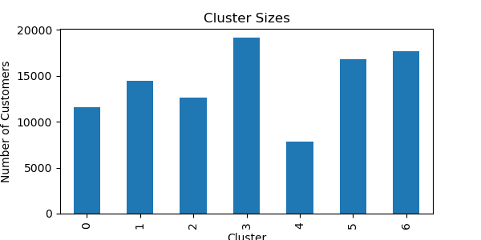

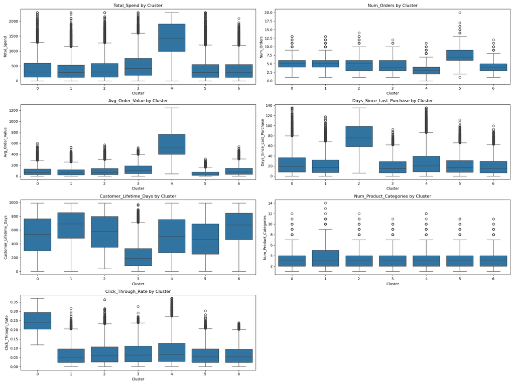

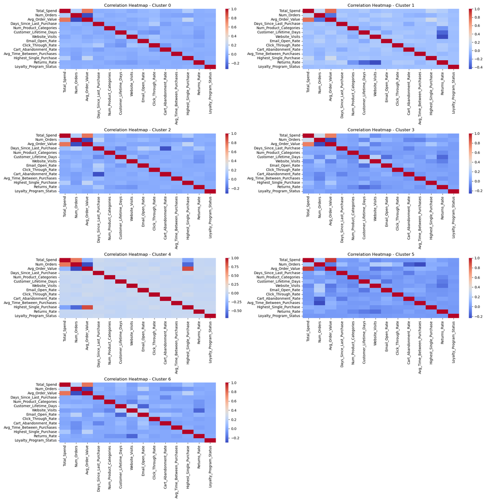

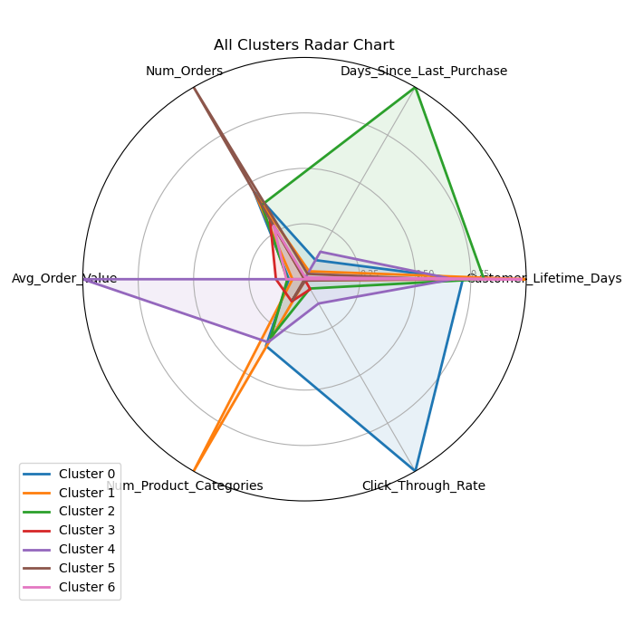

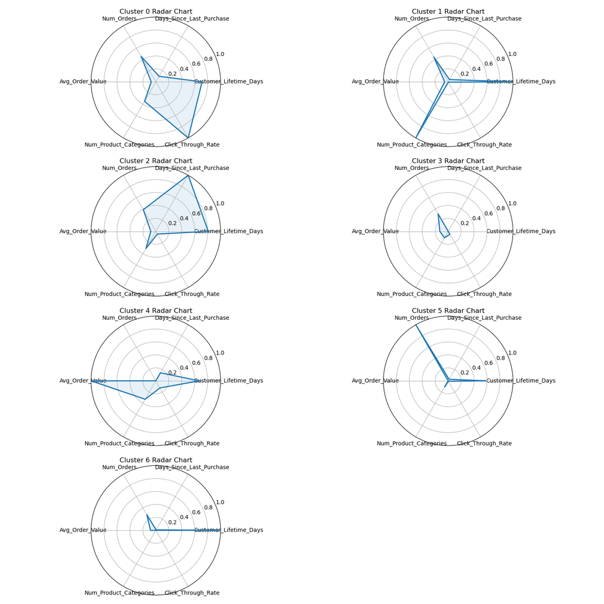

```python
from PIL import Image
from IPython.display import display

for png in ['cluster_sizes.png', 'cluster_boxplots.png', 'cluster_correlation_heatmaps.png', 'all_clusters_radar_chart.png', 'separate_clusters_radar_charts.png']:
    img = Image.open(png)
    display(img)
```

# Cluster Analysis

Let's analyze each cluster based on the centroid data and visualizations:

Cluster 0: "Average Value Customers"

Cluster 1: "Engaged Browsers"

Cluster 2: "Infrequent High-Value Shoppers"

- Higher average order value
- Longest time since last purchase
- Lower website visits and email engagement

Cluster 3: "Recent High-Value Customers"

- Second-highest total spend
- Recent purchases (lowest days since last purchase)
- Higher website visits
- Shorter customer lifetime, suggesting new customers

Cluster 4: "Big Spenders"

Cluster 5: "Frequent Low-Value Shoppers"

Cluster 6: "Loyal Email Enthusiasts"

# Strategies, Implementation, and Monitoring

1. Average Value Customers (Cluster 0):

Strategy: Increase engagement and order value

- Personalized product recommendations based on past purchases
- Loyalty program incentives for reaching higher spending tiers

Implementation:

- Develop an AI-powered recommendation engine
- Create tiered loyalty program with clear benefits

Monitoring:

- Track changes in average order value and purchase frequency
- Measure loyalty program engagement and tier progression
2. Engaged Browsers (Cluster 1):

Strategy: Convert browsing into purchases

- Implement retargeting campaigns for abandoned carts
- Offer limited-time discounts on frequently viewed items

Implementation:

- Set up automated email and ad retargeting workflows
- Develop dynamic pricing algorithms for personalized offers

Monitoring:

- Monitor cart abandonment rate and conversion rate
- Track click-through rates on retargeting campaigns
3. Infrequent High-Value Shoppers (Cluster 2):

Strategy: Increase purchase frequency

- Create exclusive "come back" offers
- Implement a VIP program with early access to new products

Implementation:

- Develop a segmented email campaign for reactivation
- Launch a VIP program with tiered benefits

Monitoring:

- Track changes in purchase frequency and time between purchases
- Measure VIP program engagement and its impact on sales
4. Recent High-Value Customers (Cluster 3):

Strategy: Nurture and retain these valuable new customers

- Provide exceptional post-purchase support
- Cross-sell complementary products

Implementation:

- Implement an automated post-purchase follow-up system
- Develop bundled offers of complementary products

Monitoring:

- Track customer retention rate and lifetime value
- Measure the success rate of cross-selling campaigns
5. Big Spenders (Cluster 4):

Strategy: Reduce cart abandonment and increase purchase frequency

- Offer free shipping or discounts on high-value carts
- Provide personal shopping assistance

Implementation:

- Implement cart abandonment triggers with incentives
- Train a dedicated team for high-value customer support

Monitoring:

- Track changes in cart abandonment rate and purchase frequency
- Measure the ROI of personal shopping assistance
6. Frequent Low-Value Shoppers (Cluster 5):

Strategy: Increase average order value

- Implement bundle deals and volume discounts
- Upsell to premium versions of frequently purchased items

Implementation:

- Develop an algorithm to create personalized bundle recommendations
- Design an upselling funnel for the checkout process

Monitoring:

- Track changes in average order value
- Measure the success rate of bundle deals and upsells
7. Loyal Email Enthusiasts (Cluster 6):

Strategy: Leverage high email engagement for increased sales

- Create exclusive email-only offers
- Implement a referral program

Implementation:

- Develop a series of targeted email campaigns with exclusive deals
- Launch a referral program with rewards for both referrer and referee

Monitoring:

- Track email campaign conversion rates
- Measure the number and value of referrals generated